# DEM 7283 - Count Data Models for individual and aggregate data

## Relative risk model

Earlier in the lesson, the epidemiological concept of relative risk was introduced, as was the concept of the expected number of cases. To calculate the expected number of low birth weight births, we can calculate the national low birth weight rate and multiply it by the number of births in each county:

```r
lbrate<-(sum(arf2018sub$lowbw1416, na.rm=T)/sum(arf2018sub$births1416, na.rm=T))
lbrate
```

```
## [1] 0.08295488
```

```r
arf2018sub$E <- lbrate* arf2018sub$births1416

head(arf2018sub[, c("coname", "births1416", "lowbw1416", "E")])
```

|  | coname | births1416 | lowbw1416 | E | geometry |
| --- | --- | --- | --- | --- | --- |
| 1 | Grimes | 339 | 32 | 28.12170 |  |
| 2 | Hidalgo | 15800 | 1304 | 1310.68705 |  |
| 3 | Houston | 231 | 19 | 19.16258 |  |
| 4 | Kleberg | 445 | 34 | 36.91492 |  |
| 5 | Lamar | 692 | 63 | 57.40477 |  |
| 6 | Newton | 138 | 12 | 11.44777 |  |

This shows us the observed number of low birth weight births, and the expected number. These are usually pretty similar. You can calculate the *relative risk* as $RR = \frac{y}{E}$, below we compare the observed number of births to the standardized number.

The first plot basically shows that the distribution is very right- skewed, and is conflated with the overall number of births in the county. While the second plot control for the number of births in the county through the expected value, and the distribution is centered around 1.

We see that some counties have higher than expected risk $\frac{y}{E} >1$ and some counties have lower risk, $\frac{y}{E} <1$. Often times, the goal of population epidemiology is to identify factors that are related to patterns of excess risk.

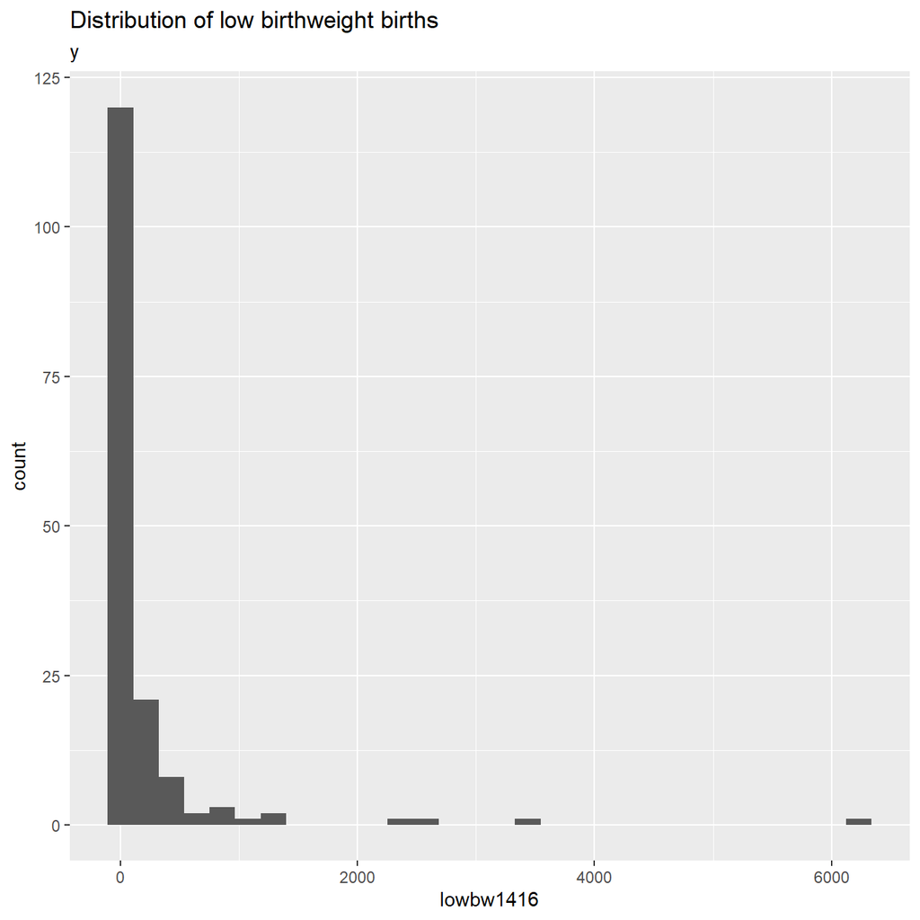

```r
arf2018sub%>%
  ggplot( aes(lowbw1416))+geom_histogram()+ggtitle("Distribution of low birthweight births", "y")
```

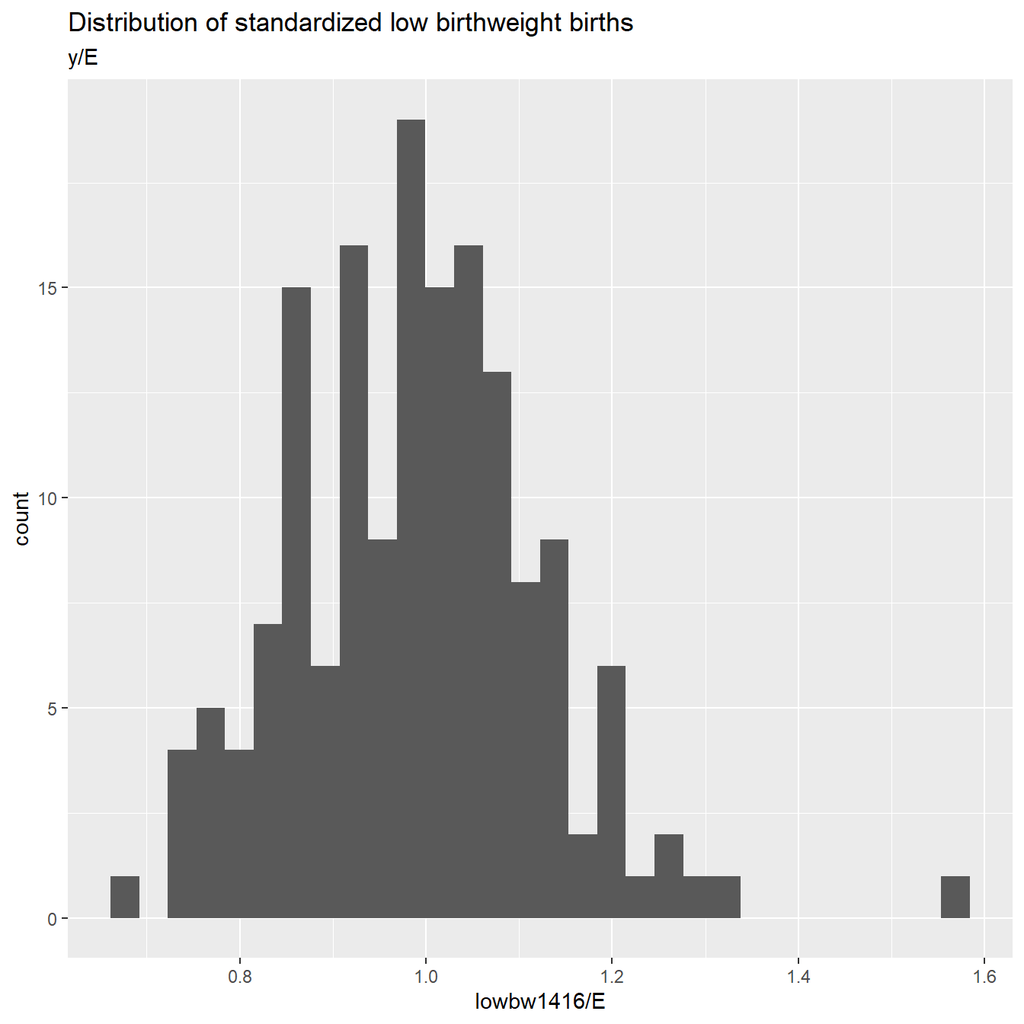

```r
arf2018sub%>%
  ggplot( aes(lowbw1416/E))+geom_histogram()+ggtitle("Distribution of standardized low birthweight births", "y/E")
```

In order to estimate the model with the expected counts, you change the offset term in the model, otherwise everything is the same:

```r
fit_pois_E<-glm(lowbw1416 ~ offset(log(E+.000001)) + hpsa10,
               family=poisson,
               data=arf2018sub)
summary(fit_pois_E)
```

```
##
## Call:
## glm(formula = lowbw1416 ~ offset(log(E + 1e-06)) + hpsa10, family = poisson,
##     data = arf2018sub)
##
## Deviance Residuals:
##     Min       1Q   Median       3Q      Max
## -4.0928  -0.5288  -0.0534   0.5404   4.0552
##
## Coefficients:
##              Estimate Std. Error z value Pr(>|z|)
## (Intercept) -0.038871   0.018273  -2.127  0.03340 *
## hpsa101      0.056675   0.019503   2.906  0.00366 **
## hpsa102      0.007692   0.021337   0.360  0.71848
## ---
## Signif. codes:  0 '***' 0.001 '**' 0.01 '*' 0.05 '.' 0.1 ' ' 1
##
## (Dispersion parameter for poisson family taken to be 1)
##
##     Null deviance: 200.20  on 160  degrees of freedom
## Residual deviance: 180.74  on 158  degrees of freedom
## AIC: 1128.7
##
## Number of Fisher Scoring iterations: 4
```

In fact, these results are identical to those from the Poisson model with the births as the offset term.

## Binomial count model

The binomial model described earlier in the lesson can also be fit with the `glm()` function. In order to identify the numerator and the denominator, we have to specify the outcome in the model a little differently:

```r
fit_bin<-glm(cbind(lowbw1416 , births1416)~  hpsa10,
               family=binomial,
               data=arf2018sub)
summary(fit_bin)
```

```
##
## Call:
## glm(formula = cbind(lowbw1416, births1416) ~ hpsa10, family = binomial,
##     data = arf2018sub)
##
## Deviance Residuals:
##     Min       1Q   Median       3Q      Max
## -3.9359  -0.5087  -0.0514   0.5181   3.8900
##
## Coefficients:
##              Estimate Std. Error  z value Pr(>|z|)
## (Intercept) -2.528330   0.018988 -133.157  < 2e-16 ***
## hpsa101      0.056675   0.020271    2.796  0.00518 **
## hpsa102      0.007692   0.022173    0.347  0.72868
## ---
## Signif. codes:  0 '***' 0.001 '**' 0.01 '*' 0.05 '.' 0.1 ' ' 1
##
## (Dispersion parameter for binomial family taken to be 1)
##
##     Null deviance: 185.07  on 160  degrees of freedom
## Residual deviance: 167.10  on 158  degrees of freedom
## AIC: 1102.4
##
## Number of Fisher Scoring iterations: 3
```

In this model, we see the exact same results compared to the Poisson model. The only difference is the AIC for the binomial model is substantially lower, suggesting that that distribution is preferred in this analysis.